# Effects of borrowers' financial background on their APR

## Dataset Overview

> The data consisted of APR and attributes related to loans during 2007-2014 of approximately 110,000 loans and 81 variables including term, date, APR and information about the borrowers such as income range and available bank card credit when open the current loan. We'll pick up around 10 variables to do further analysis and see what's affecting borrower APR. The data that BankCardUtilization is more than 1 has been removed.

## Distribution of Borrower APR

> The BorrowerAPR distribution looks bimodal,with the first peak 0.1-0.2 and second peak(even more) 0.3-0.4. Most of the loan APRs are in 0.1-0.3, but the second peak is an exception and need more attention.

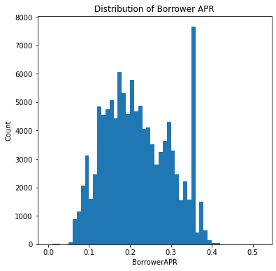

## BorrowerAPR by LoanStatus, IncomeRange and Term

> Clearly, `IncomeRange` seems to be most relevant to the `BorrowerAPR`, with lower income, the APR goes up except when income range is $'0'$. There may be some input error for the $'0'$ as it equals to $'not$ $employed'$. So this exception won't change our conclusion. Term has little effect on the APR. High APR loans are usually easier to be 'past due', which means APR can represent risk level.

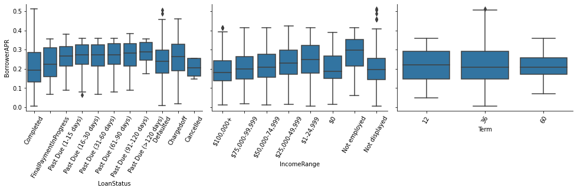

## Montly Loan Payment by Income Range

There's a declining trend of MonthlyLoanPayment when the income declines, but not very significant.

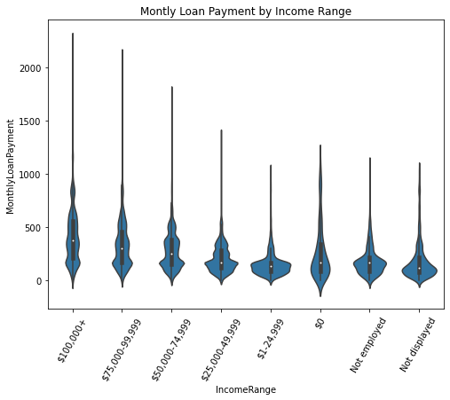

## Available Bank Card Credit by Income Range

There's a declining trend of available bank card credit when the income declines, but not very significant.

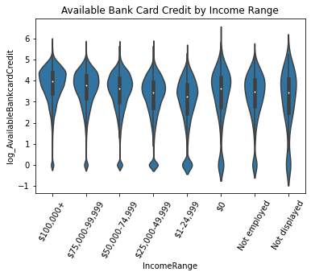

## Relationship among Income Range, Available Bank Card Credit and Monthly Loan Payment

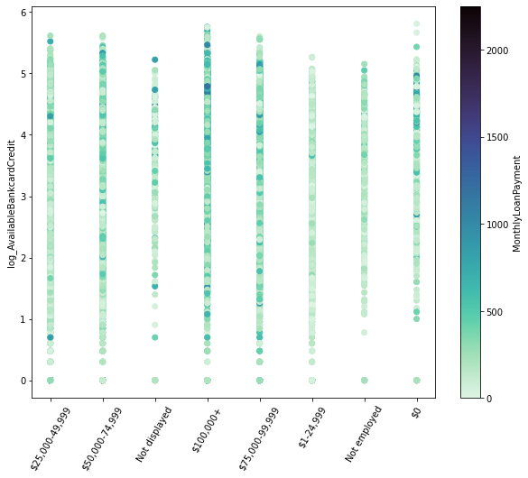

## APR by IncomeRange and Term

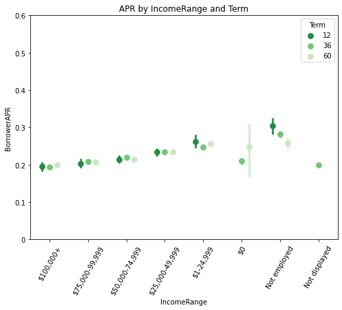